# 아마존과 경쟁하는 CVS 기업분석

CVS의 주가가 계속해서 하락하고 있다. 지금 이 순간, CVS에 투자할 기회인가?

> 이 포스팅에서는 CVS라는 기업의 최근 10년 실적과 현재의 위기 상황, 그리고 미래에 대해 알아본다. 기업의 미래에 대해 정확하게 예측할 수는 없지만 대략적으로는 추정할 수 있다. 특히 시장이 최악의 상황을 예상하는 가운데 싸게 매수하여 상황이 호전되었을 때 매도하면 큰 차익을 거둘 수 있는데 CVS가 그런 기업에 해당하는 지 함께 살펴보자.

## CVS

CVS는 CVS Pharmacy의 티커다. 이 기업은 미국에서 약국을 운영하고 있는 기업이다. 의사를 자주 만나지 못하는 환자들에게 약의 복용 순응도를 높이고 건강상담 등을 제공하며 빠르게 성장했다. 10년 전 부터는 환자에게 약을 주사하거나 1차 진료를 위한 비즈니스를 인수하면서 그 성장세가 더 가팔라졌다. 그런데 최근 주식의 가격은 하락세를 면치 못하고 있다.

### CVS의 매출액

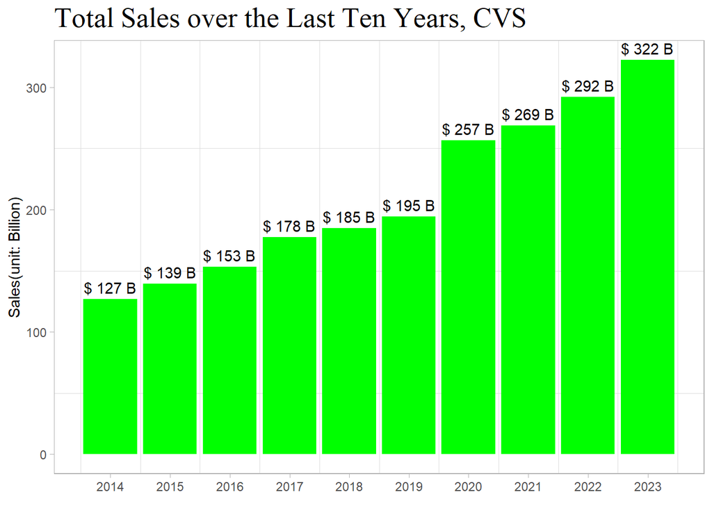

매출은 꾸준히 증가하는 모양이다. 경영진의 우려에도 2023년까지도 매출은 계속해서 성장해왔다. 판데믹 이후 급격하게 늘어난 의료비용이 다시 줄어들 것으로 사람들은 예상했으나 그렇지 않았다. 의료비용은 계속해서 증가했다. 인플레이션에도 끄떡 없이 말이다. 인플레이션에 맞춰 매출이 증가하는 기업은 비즈니스모델이 아주 강력한 기업이라 할 수 있다.

### CVS의 영업이익

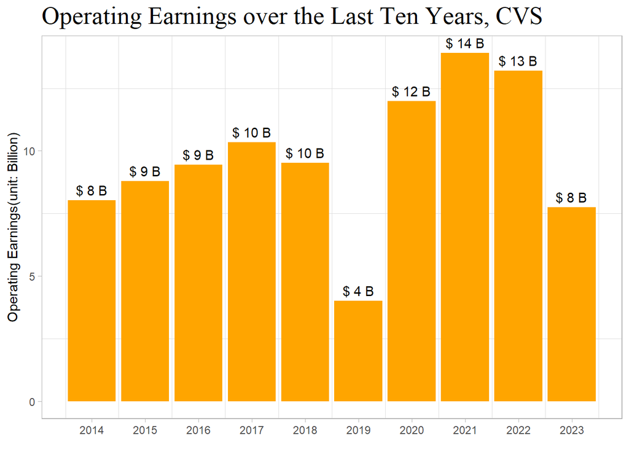

최근 10년 간의 영업이익은 최근 감소하는 모습을 보이고 있다. 2021년을 정점으로 이후 급격하게 감소되는 모양이다. 이에 대해 두가지 원인을 생각해 볼 수 있는데, 첫째는 아마존과의 경쟁이고, 둘째는 인플레이션에 의한 마진 압박이다.

아마존에 대해 우려가 많지만, 사실 과도한 우려라고 본다. 아마존이 세상을 지배할 것 같았고, 유통계를 지배할 줄 알았지만 지금까지도 코스트코와 홈디포, 로우스 등 미국에서는 아주 잘 해내고 있다. 오히려 주가도 많이 올랐다. CVS도 잔뼈가 굵은 회사로 아마존에 의해 쉽게 무너질 거라 단정하긴 어렵다.

인플레이션도 잠시 지나가는 흐름으로 본다. 결국 증가된 의료비용은 판매단가 이상 등의 요소로 CVS의 마진으로 더해질 것이고 이익력도 회복하리라 본다.

### 영업이익률

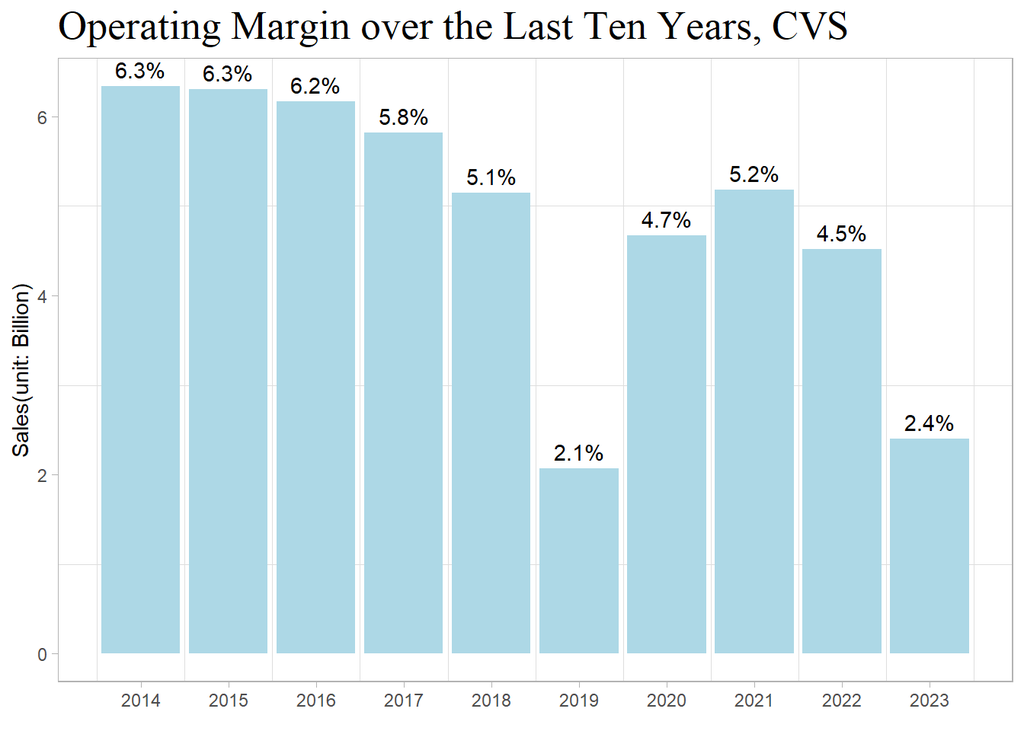

과거부터 영업이익률은 그렇게 높지 않았다. 그런데 최근 그 낮던 영업이익률 마저 더 낮아지는 모양이다. 판매가 인상과 경영 효율성 증대로 이익을 유지하는 게 중요하겠다.

### 현금흐름 추이

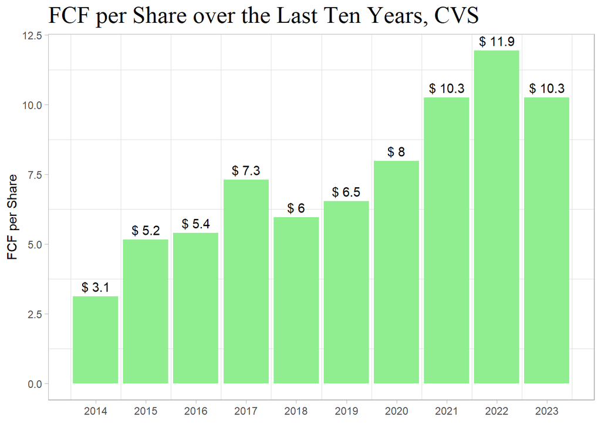

현금흐름은 아주 훌륭하다. 현재 주가 74달러를 고려하면 FCF/Price 비율이 10%를 넘는다. 제 아무리 급격하게 성장하기 어려운 비즈니스라고 하지만 이정도 주가는 과도하다. 만약 FCF가 7달러까지 하락하고 더 이상의 성장이 어려워 이익의 70% 를 배당한다면, 배당수익률은 7%다. 지금 수준에서는 `거의 잃을 게 없는 가격`이다. 그래서 필자는 꾸준히 매수하고 있다.

### 희석 유통 주식수

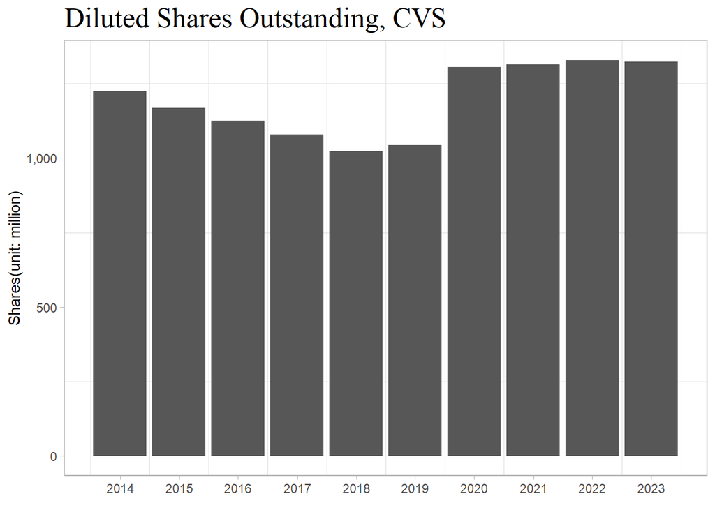

주식 수는 2020년 급격하게 치솟았지만 안정세를 보이고 있다. 2014년에는 꾸준한 자사주 매입으로 유통물량이 감소해온 점을 고려하면 다소 아쉽다. 만약 경영진이 CVS 사업의 미래를 그렇게 밝게 보지 않는다면, 세금 비용이 발생하는 배당보다는 자사주 매입으로 잉여현금흐름을 지혜롭게 사용해주었으면 하는 바람이다.

### 결론

CVS라는 기업에 대해 살펴보았는데, 영업이익과 영업이익률은 다소 감소하는 추세이지만, 매출이 꾸준히 증가하고 있고 배당도 잘하고 무엇보다, `훌륭한 FCF와 FCF/Price ratio가 일품`이다. FCF/Price ratio 가 0.1, 그러니까 10% 이하에서는 매수해도 크게 잃을 게 없다. 기업이 성장하지 못한다면 배당을 해버리면 그만이기 때문이다. 이익이 유지되기만 한다면 배당수익률로 인해 주가의 하방은 탄탄해진다. 지금의 이익조차 유지되지 않을거라 우려하기엔 CVS 기업의 역사와 트랙 레코드가 너무 훌륭하다는 생각이다.